# R Notebook

# Análisis Exploratorio Autos

```r
library(GGally)
```

[output not shown]

```r
source("metadata.R"  , encoding = 'UTF-8')
source("utils.R"     , encoding = 'UTF-8')
source("00-load.R"   , encoding = 'UTF-8')
```

```
autos.rds ya existe
```

```r
source("01-prepare.R", encoding = 'UTF-8')
```

```r
autos_data[problematic_rows,]
```

| symboling | normalized-losses | make | fuel-type | aspiration | num-of-doors | body-style | drive-wheels | engine-location | wheel-base | length | width | height | curb-weight | engine-type | num-of-cylinders | engine-size | fuel-system | bore | stroke | compression-ratio | horsepower | peak-rpm | city-mpg | highway-mpg | price |
| --- | --- | --- | --- | --- | --- | --- | --- | --- | --- | --- | --- | --- | --- | --- | --- | --- | --- | --- | --- | --- | --- | --- | --- | --- | --- |
| 3 | 150 | mazda | gas | std | two | hatchback | rwd | front | 95.3 | 169.0 | 65.7 | 49.6 | 2385rotor | two | 70 | 4bbl | NA | NA | 9.4 | 101 | 6000 | 17 | 23 | 13645 | NA |
| 1 | 129 | mazda | gas | std | two | hatchback | fwd | front | 98.8 | 177.8 | 66.5 | 53.7 | 2385ohc | four | 122 | 2bbl | 3.39 | 3.39 | 8.6 | 84 | 4800 | 26 | 32 | 10595 | NA |
| -1 | NA | mercedes-benz | gas | std | four | sedan | rwd | front | 115.6 | 202.6 | 71.7 | 56.5 | 3740ohcv | eight | 234 | mpfi | 3.46 | 3.10 | 8.3 | 155 | 4750 | 16 | 18 | 34184 | NA |
| 3 | NA | mitsubishi | gas | turbo | two | hatchback | fwd | front | 95.9 | 173.2 | 66.3 | 50.2 | 2921ohc | four | 156 | spdi | 3.59 | 3.86 | 7.0 | 145 | 5000 | 19 | 24 | 14869 | NA |
| 1 | 119 | plymouth | gas | turbo | two | hatchback | fwd | front | 93.7 | 157.3 | 63.8 | 50.8 | 2128ohc | four | 98 | spdi | 3.03 | 3.39 | 7.6 | 102 | 5500 | 24 | 30 | 7957 | NA |
| 0 | 89 | subaru | gas | std | four | wagon | fwd | front | 97 | 173.5 | 65.4 | 53.0 | 2290ohcf | four | 108 | 2bbl | 3.62 | 2.64 | 9.0 | 82 | 4800 | 28 | 32 | 7463 | NA |

```r
source("02-clean.R",   encoding = 'UTF-8')
```

[output not shown]

```r
autos_data[problematic_rows,]
```

| symboling | normalized_losses | make | fuel_type | aspiration | num_of_doors | body_style | drive_wheels | engine_location | wheel_base | length | width | height | curb_weight | engine_type | num_of_cylinders | engine_size | fuel_system | bore | stroke | compression_ratio | horsepower | peak_rpm | city_mpg | highway_mpg | price |
| --- | --- | --- | --- | --- | --- | --- | --- | --- | --- | --- | --- | --- | --- | --- | --- | --- | --- | --- | --- | --- | --- | --- | --- | --- | --- |
| 3 | 150 | mazda | gas | std | two | hatchback | rwd | front | 95.3 | 169.0 | 65.7 | 49.6 | 2385 | rotor | two | 70 | 4bbl | NA | NA | 9.4 | 101 | 6000 | 17 | 23 | 13645 |
| 1 | 129 | mazda | gas | std | two | hatchback | fwd | front | 98.8 | 177.8 | 66.5 | 53.7 | 2385 | ohc | four | 122 | 2bbl | 3.39 | 3.39 | 8.6 | 84 | 4800 | 26 | 32 | 10595 |
| -1 | NA | mercedes-benz | gas | std | four | sedan | rwd | front | 115.6 | 202.6 | 71.7 | 56.5 | 3740 | ohcv | eight | 234 | mpfi | 3.46 | 3.10 | 8.3 | 155 | 4750 | 16 | 18 | 34184 |
| 3 | NA | mitsubishi | gas | turbo | two | hatchback | fwd | front | 95.9 | 173.2 | 66.3 | 50.2 | 2921 | ohc | four | 156 | spdi | 3.59 | 3.86 | 7.0 | 145 | 5000 | 19 | 24 | 14869 |
| 1 | 119 | plymouth | gas | turbo | two | hatchback | fwd | front | 93.7 | 157.3 | 63.8 | 50.8 | 2128 | ohc | four | 98 | spdi | 3.03 | 3.39 | 7.6 | 102 | 5500 | 24 | 30 | 7957 |
| 0 | 89 | subaru | gas | std | four | wagon | fwd | front | 97 | 173.5 | 65.4 | 53.0 | 2290 | ohcf | four | 108 | 2bbl | 3.62 | 2.64 | 9.0 | 82 | 4800 | 28 | 32 | 7463 |

### La codificación del archivo imports-85.names es: ASCII text

### La codificación del archivo imports-85.csv es: ASCII text

#### Imputamos por similitud los valores NA

```r
autos_data<-autos_data %>% mutate_at(c(3,4,5,6,7,8,9,10,15,16,18),list(as.factor))
autos_data<-imputar_por_similitud(autos_data,5)
autos_data[!complete.cases(autos_data),]
```

| symboling | normalized_losses | make | fuel_type | aspiration | num_of_doors | body_style | drive_wheels | engine_location | wheel_base | length | width | height | curb_weight | engine_type | num_of_cylinders | engine_size | fuel_system | bore | stroke | compression_ratio | horsepower | peak_rpm | city_mpg | highway_mpg | price | row_num |
| --- | --- | --- | --- | --- | --- | --- | --- | --- | --- | --- | --- | --- | --- | --- | --- | --- | --- | --- | --- | --- | --- | --- | --- | --- | --- | --- |

#### Notamos que hay un problema en la columna wheel-base que tiene un String que hace que la columna se lea como factor.

```r
glimpse(autos_data)
```

```
Rows: 205
Columns: 27
$ symboling         <dbl> 3, 3, 1, 2, 2, 2, 1, 1, 1, 0, 2,...
$ normalized_losses <dbl> 125.6, 125.6, 121.8, 164.0, 164....
$ make              <fct> alfa-romero, alfa-romero, alfa-r...
$ fuel_type         <fct> gas, gas, gas, gas, gas, gas, ga...
$ aspiration        <fct> std, std, std, std, std, std, st...
$ num_of_doors      <fct> two, two, two, four, four, two, ...
$ body_style        <fct> convertible, convertible, hatchb...
$ drive_wheels      <fct> rwd, rwd, rwd, fwd, 4wd, fwd, fw...
$ engine_location   <fct> front, front, front, front, fron...
$ wheel_base        <fct> 88.6, 88.6, 94.5, 99.8, 99.4, 99...
$ length            <dbl> 168.8, 168.8, 171.2, 176.6, 176....
$ width             <dbl> 64.1, 64.1, 65.5, 66.2, 66.4, 66...
$ height            <dbl> 48.8, 48.8, 52.4, 54.3, 54.3, 53...
$ curb_weight       <dbl> 2548, 2548, 2823, 2337, 2824, 25...
$ engine_type       <fct> dohc, dohc, ohcv, ohc, ohc, ohc,...
$ num_of_cylinders  <fct> four, four, six, four, five, fiv...
$ engine_size       <dbl> 130, 130, 152, 109, 136, 136, 13...
$ fuel_system       <fct> mpfi, mpfi, mpfi, mpfi, mpfi, mp...
$ bore              <dbl> 3.47, 3.47, 2.68, 3.19, 3.19, 3....
$ stroke            <dbl> 2.68, 2.68, 3.47, 3.40, 3.40, 3....
$ compression_ratio <dbl> 9.0, 9.0, 9.0, 10.0, 8.0, 8.5, 8...
$ horsepower        <dbl> 111, 111, 154, 102, 115, 110, 11...
$ peak_rpm          <dbl> 5000, 5000, 5000, 5500, 5500, 55...
$ city_mpg          <dbl> 21, 21, 19, 24, 18, 19, 19, 19, ...
$ highway_mpg       <dbl> 27, 27, 26, 30, 22, 25, 25, 25, ...
$ price             <dbl> 13495.0, 16500.0, 16500.0, 13950...
$ row_num           <int> 1, 2, 3, 4, 5, 6, 7, 8, 9, 10, 1...
```

#### Corregimos dicho error

```r
autos_data$wheel_base<-as.numeric(as.character(autos_data$wheel_base))
```

```
NAs introducidos por coerci昼㸳n
```

```r
autos_data[157,10]<-95.7
summary(autos_data)
```

```
   symboling       normalized_losses         make
 Min.   :-2.0000   Min.   : 65.0     toyota    : 32
 1st Qu.: 0.0000   1st Qu.:101.0     nissan    : 18
 Median : 1.0000   Median :121.8     mazda     : 17
 Mean   : 0.8341   Mean   :122.4     honda     : 13
 3rd Qu.: 2.0000   3rd Qu.:137.0     mitsubishi: 13
 Max.   : 3.0000   Max.   :256.0     subaru    : 12
                                     (Other)   :100
  fuel_type   aspiration  num_of_doors       body_style
 diesel: 20   std  :168   four:114     convertible: 6
 gas   :185   turbo: 37   two : 91     hardtop    : 8
                                       hatchback  :70
                                       sedan      :96
                                       wagon      :25


 drive_wheels engine_location   wheel_base         length
 4wd:  9      front:202       Min.   : 86.60   Min.   :141.1
 fwd:120      rear :  3       1st Qu.: 94.50   1st Qu.:166.3
 rwd: 76                      Median : 97.00   Median :173.2
                              Mean   : 98.76   Mean   :174.0
                              3rd Qu.:102.40   3rd Qu.:183.1
                              Max.   :120.90   Max.   :208.1

     width           height       curb_weight     engine_type
 Min.   :60.30   Min.   :47.80   Min.   :  1488   dohc : 12
 1st Qu.:64.10   1st Qu.:52.00   1st Qu.:  2169   dohcv:  1
 Median :65.50   Median :54.10   Median :  2420   l    : 12
 Mean   :65.91   Mean   :53.72   Mean   :  7858   ohc  :148
 3rd Qu.:66.90   3rd Qu.:55.50   3rd Qu.:  2954   ohcf : 15
 Max.   :72.30   Max.   :59.80   Max.   :338000   ohcv : 13
                                                  rotor:  4
 num_of_cylinders  engine_size     fuel_system      bore
 eight :  5       Min.   : 61.0   mpfi   :94   Min.   :2.54
 five  : 11       1st Qu.: 97.0   2bbl   :66   1st Qu.:3.15
 four  :159       Median :120.0   idi    :20   Median :3.31
 six   : 24       Mean   :126.9   1bbl   :11   Mean   :3.33
 three :  1       3rd Qu.:141.0   spdi   : 9   3rd Qu.:3.58
 twelve:  1       Max.   :326.0   4bbl   : 3   Max.   :3.94
 two   :  4                       (Other): 2
```

[output cut: 8 more lines]

```
    peak_rpm       city_mpg      highway_mpg
 Min.   :4150   Min.   :13.00   Min.   :16.00
 1st Qu.:4800   1st Qu.:19.00   1st Qu.:25.00
 Median :5200   Median :24.00   Median :30.00
 Mean   :5122   Mean   :25.22   Mean   :30.75
 3rd Qu.:5500   3rd Qu.:30.00   3rd Qu.:34.00
 Max.   :6600   Max.   :49.00   Max.   :54.00

     price          row_num
 Min.   : 5118   Min.   :  1
 1st Qu.: 7788   1st Qu.: 52
 Median :10345   Median :103
 Mean   :13263   Mean   :103
 3rd Qu.:16503   3rd Qu.:154
 Max.   :45400   Max.   :205
```

## Análisis Univariado

### Histogramas

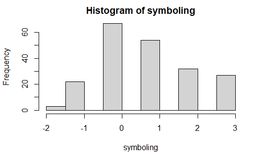

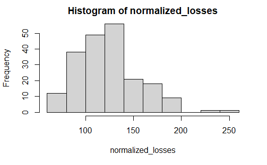

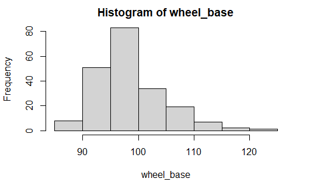

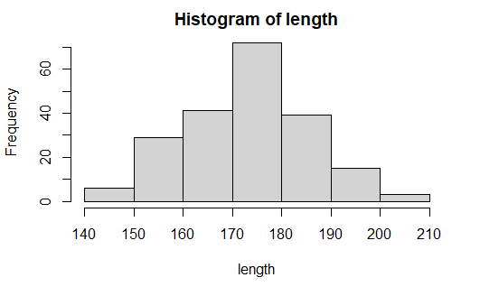

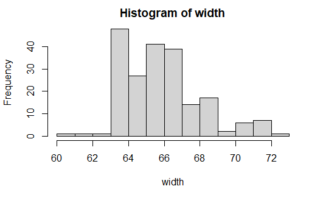

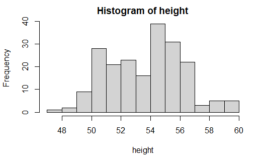

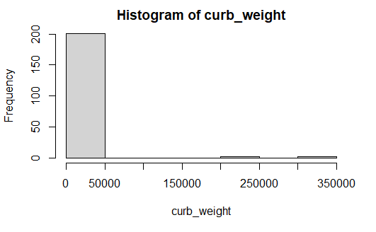

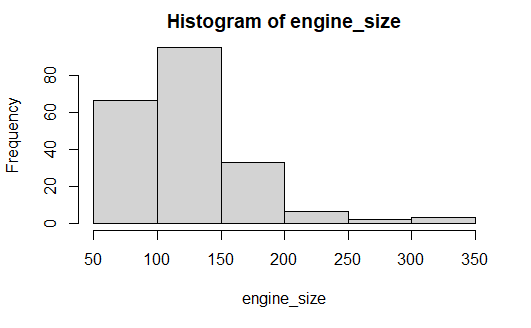

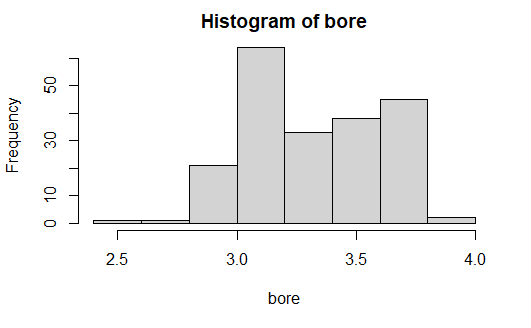

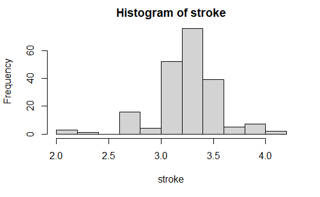

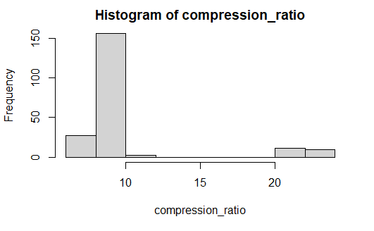

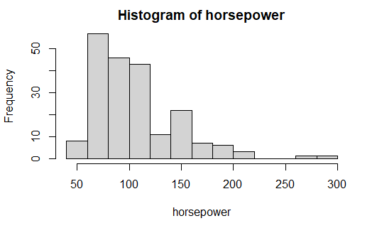

[5 more figures not shown]

```r
for(col in colnames(select_if(autos_data,is.numeric))){
  hist(t(autos_data[col]),main = sprintf("Histogram of %s",col), xlab =sprintf("%s",col))
}
```

#### Podemos ver datos atípicos en Curb-Weight, podemos ver que casi todas las variables son monomodales, a excepción de Height y Peak-RPM. Podemos apreciar también que en su mayoría las variables son asimétricas, excepto Stroke y Length. El Precio parece seguir una distribución exponencial.

### Gráficas de Frecuencia para Variables Categóricas

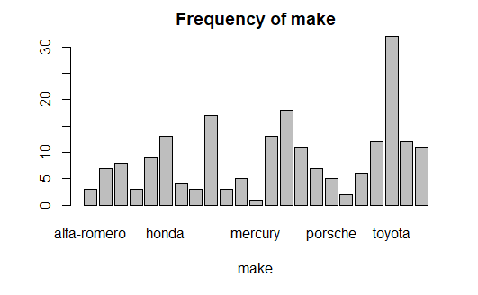

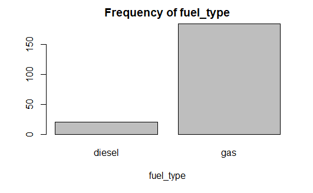

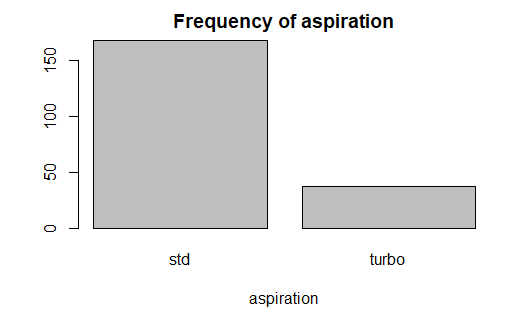

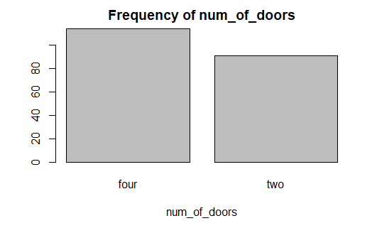

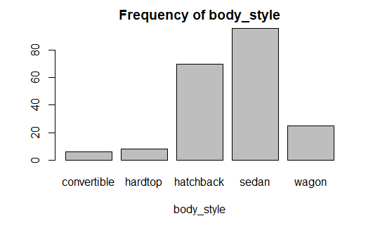

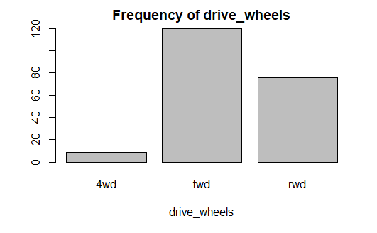

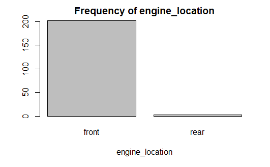

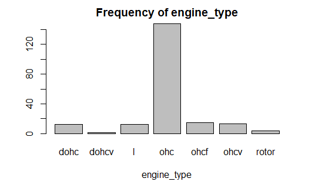

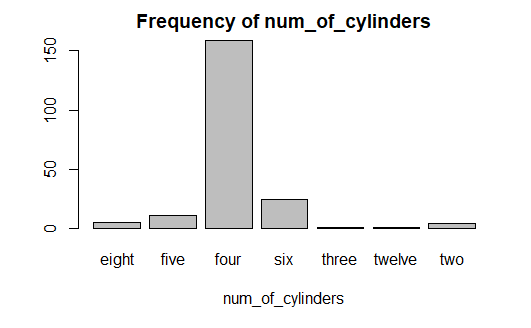

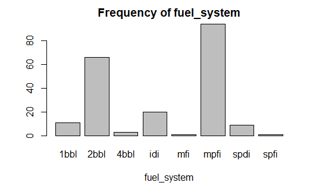

```r
for(col in colnames(select_if(autos_data,is.factor))){
  barplot(table(autos_data[col]),main = sprintf("Frequency of %s",col), xlab =sprintf("%s",col))
}
```

#### Debemos poner especial atención a los valores con poca frecuencia que tengan precios altos, ya que podría haber atributos que eleven el precio del auto simplemente por ser más costosos en la producción